# spatial_hw

Hannah Houston and Ansley Williamson

2023-02-28

## Spatial Modeling Assignment

```r
library(vegan)
library(nlme)
library(gstat)

data(BCI)
## UTM Coordinates (in metres)
BCI_xy = data.frame(x = rep(seq(625754, 626654, by=100), each=5),
                    y = rep(seq(1011569,  1011969, by=100), len=50))
```

1. Examine if there is evidence of spatial dependence in a rare and a common species in the BCI tree dataset

```r
# look at species ranks based upon number of occurrences
abundance <- sort(colSums(BCI > 0), dec = T)
abundance
```

```
##                 Alseis.blackiana             Faramea.occidentalis
##                               50                               50
##                Hirtella.triandra                Oenocarpus.mapora
##                               50                               50
##              Protium.tenuifolium          Tetragastris.panamensis
##                               50                               50
##            Trichilia.tuberculata                    Apeiba.glabra
##                               50                               49
##                 Gustavia.superba              Pouteria.reticulata
##                               49                               49
##           Quararibea.asterolepis                    Randia.armata
##                               49                               49
##              Brosimum.alicastrum                Cordia.lasiocalyx
##                               48                               48
##              Eugenia.oerstediana                  Guarea.guidonia
##                               48                               48
##             Hasseltia.floribunda               Heisteria.concinna
##                               48                               48
##          Tabernaemontana.arborea                   Cordia.bicolor
##                               48                               47
##                 Jacaranda.copaia                  Virola.sebifera
##                               47                               47
##         Astrocaryum.standleyanum              Guatteria.dumetorum
##                               46                               46
##                 Poulsenia.armata                  Simarouba.amara
##                               46                               46
##            Beilschmiedia.pendula        Lonchocarpus.heptaphyllus
##                               45                               45
##   Maquira.guianensis.costaricana              Virola.surinamensis
##                               45                               45
##          Alchornea.costaricensis                Cecropia.insignis
##                               44                               44
##               Guapira.myrtiflora                Prioria.copaifera
##                               44                               43
## Swartzia.simplex.var.grandiflora             Tachigali.versicolor
##                               43                               43
##               Pterocarpus.rohrii          Chrysophyllum.argenteum
##                               42                               41
##   Swartzia.simplex.continentalis                  Eugenia.florida
##                               41                               40
```

[output cut: 171 more lines]

```
##                                1                                1
##             Colubrina.glandulosa                  Cupania.cinerea
##                                1                                1
##                 Ficus.colubrinae                    Miconia.elata
##                                1                                1
##                Ormosia.amazonica                  Pachira.quinata
##                                1                                1
##                 Pachira.sessilis               Psychotria.grandis
##                                1                                1
##                  Senna.dariensis                  Talisia.nervosa
##                                1                                1
##          Trichospermum.galeottii                 Vismia.baccifera
##                                1                                1
##            Zanthoxylum.setulosum
##                                1
```

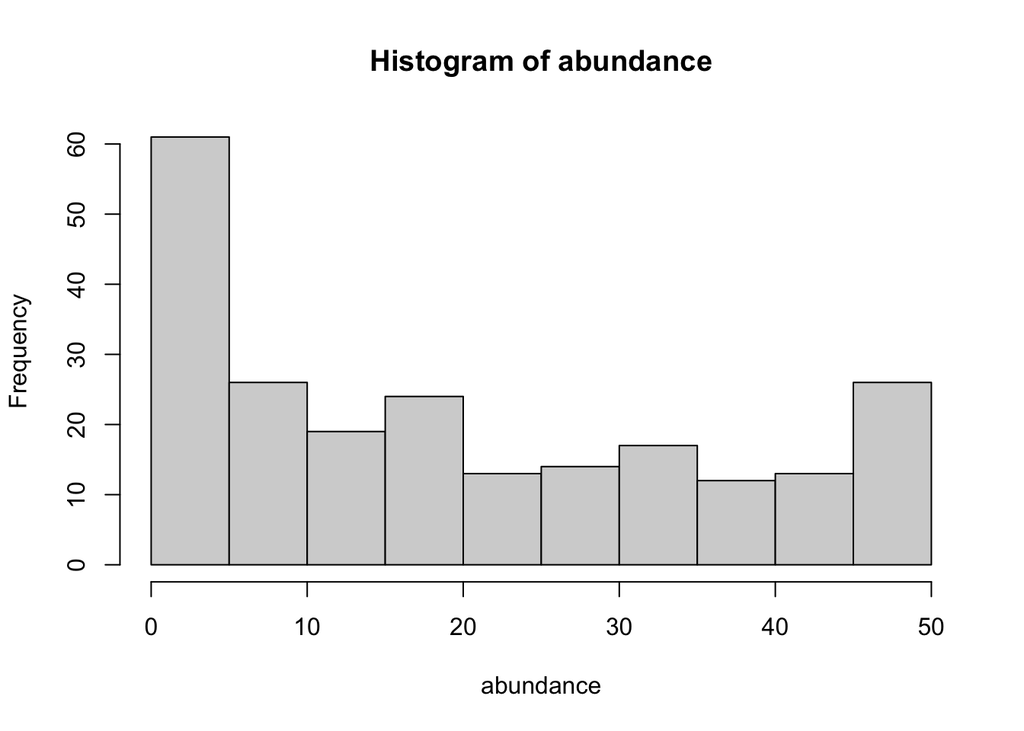

```r
hist(abundance, mainlab= "Species Abundance Distribution")
```

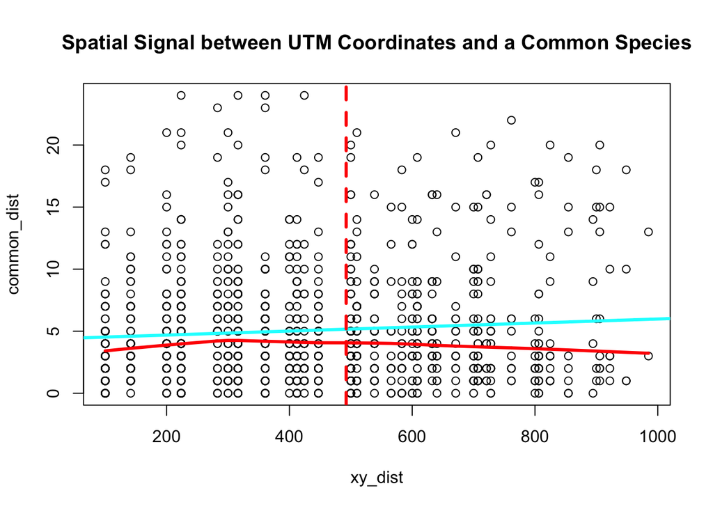

```r
#common species will be Tetragastris.panamensis (count is at 50) and rare species will be Inga.umbellifera (count is at 12)

#calculate Euclidean distances and plot
rare_dist <- dist(BCI$Inga.umbellifera, method = "euclidean")
common_dist <- dist(BCI$Tetragastris.panamensis, method = "euclidean")
xy_dist <- dist(BCI_xy)

max_dist <- max(xy_dist) / 2

#make a plot to look at spatial signal
plot(xy_dist, common_dist, main = "Spatial Signal between UTM Coordinates and a Common Species")
abline(lm(common_dist ~ xy_dist), lwd=3, col='cyan')
lines(lowess(xy_dist, common_dist), lwd=3, col='red')
abline(v = max_dist, col='red', lwd=3, lty=2)
```

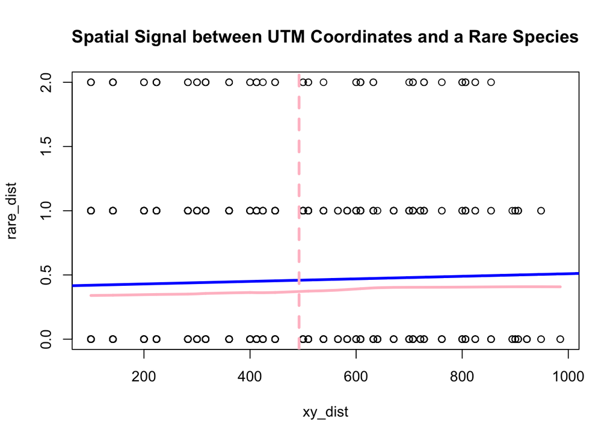

```r
plot(xy_dist, rare_dist, main = "Spatial Signal between UTM Coordinates and a Rare Species")
abline(lm(rare_dist ~ xy_dist), lwd=3, col='blue')
lines(lowess(xy_dist, rare_dist), lwd=3, col='pink')
abline(v = max_dist, col='pink', lwd=3, lty=2)
```

```r
# compute correlation
obs_cor_com_rare <- cor(xy_dist, rare_dist)
obs_cor_com_rare #this is 0.0345
```

```
## [1] 0.03449564
```

```r
#this shows a weak correlation close to 0, suggests a random spatial signal. Still not sold so I will check with permutations

obs_cor_common <- cor(xy_dist, common_dist)
obs_cor_common #this is 0.076
```

```
## [1] 0.07643858
```

```r
#this shows a weak correlation close to 0, suggests a random spatial signal. Still not sold so I will check with permutations

#carry out mantel test for permutations, does 999 automatically, develops a null distribution of correlation values
rare_mantel <- mantel(xy_dist, rare_dist)
rare_mantel
```

```
##
## Mantel statistic based on Pearson's product-moment correlation
##
## Call:
## mantel(xdis = xy_dist, ydis = rare_dist)
##
## Mantel statistic r: 0.0345
##       Significance: 0.277
##
## Upper quantiles of permutations (null model):
##    90%    95%  97.5%    99%
## 0.0806 0.1061 0.1267 0.1483
## Permutation: free
## Number of permutations: 999
```

```r
#not significant, shows a random spatial signal

common_mantel <- mantel(xy_dist, common_dist)
common_mantel
```

```
##
## Mantel statistic based on Pearson's product-moment correlation
##
## Call:
## mantel(xdis = xy_dist, ydis = common_dist)
##
## Mantel statistic r: 0.07644
##       Significance: 0.123
##
## Upper quantiles of permutations (null model):
##    90%    95%  97.5%    99%
## 0.0841 0.1057 0.1311 0.1460
## Permutation: free
## Number of permutations: 999
```

```r
#not significant, shows a random spatial signal
```

2. Build two generalized linear models to predict the abundance of the species *Drypetes standleyi* using the abundance of other tree species in the study site. Specifically examine the following species as predictor variables:

```r
sp_ids = c("Cordia.lasiocalyx", "Hirtella.triandra",
           "Picramnia.latifolia", "Quassia.amara",
           "Tabernaemontana.arborea", "Trattinnickia.aspera",
           "Xylopia.macrantha")
```

With both models examine the spatial dependence of the residuals using the function `Variogram`. Model the spatial dependence in the residuals using one of the error structures available.

- Model 1: only include a single species as a predictor variable

```r
#subset the data to include only the species and spatial location we are interested in
dry_sta <- subset(BCI, select = c("Drypetes.standleyi", "Cordia.lasiocalyx", "Hirtella.triandra",
         "Picramnia.latifolia", "Quassia.amara", "Tabernaemontana.arborea" , "Trattinnickia.aspera", "Xylopia.macrantha"))
bci_sub <- cbind(dry_sta, BCI_xy)

#Making Model 1: only include a single species as a predictor variable

gls_onesp <- gls(Drypetes.standleyi ~ Cordia.lasiocalyx, data = bci_sub)
summary(gls_onesp)
```

```
## Generalized least squares fit by REML
##   Model: Drypetes.standleyi ~ Cordia.lasiocalyx
##   Data: bci_sub
##        AIC      BIC    logLik
##   335.1246 340.7382 -164.5623
##
## Coefficients:
##                       Value Std.Error   t-value p-value
## (Intercept)       -2.782803 1.9173184 -1.451404  0.1532
## Cordia.lasiocalyx  1.165220 0.2292289  5.083217  0.0000
##
##  Correlation:
##                   (Intr)
## Cordia.lasiocalyx -0.87
##
## Standardized residuals:
##        Min         Q1        Med         Q3        Max
## -1.8757378 -0.4356989 -0.1061361  0.1804392  4.5135685
##
## Residual standard error: 6.675561
## Degrees of freedom: 50 total; 48 residual
```

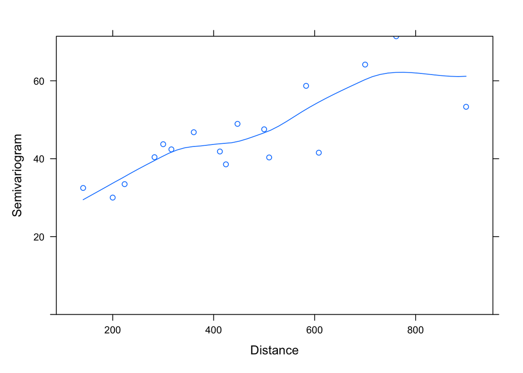

```r
#p-value is significant, absolute value of correlationis 0.87 (large), does seem to be autocorrelation between Drypetes standleyi and Cordia lasiocalyx

#Use function Variogram for one species
library(gstat)
vario_onesp <- Variogram(gls_onesp, form= ~ x + y, resType = 'response')
# note the default of the Variogram function is to compute normalized residuals
plot(vario_onesp)
```

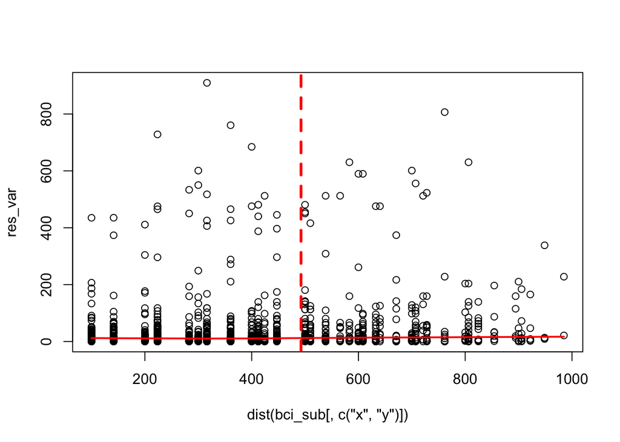

```r
#compare to a plot we make on our own
res <- residuals(gls_onesp)
res_var <- dist(res)^2 * 0.5
plot(dist(bci_sub[, c('x', 'y')]), res_var)
lines(lowess(dist(bci_sub[, c('x', 'y')]), res_var), col='red', lwd=2)
abline(v = max_dist, col='red', lwd=3, lty=2)
```

```r
#Variogram and the variogram done by hand have a positive slope, the error of the model is showing positive autocorrelation

#Model the spatial dependence in the residuals using one of the error structures available.
#try an AR1: most common model of spatial autocorrelation
onesp_exp <- update(gls_onesp, corr=corExp(form=~ x + y))
summary(onesp_exp)
```

```
## Generalized least squares fit by REML
##   Model: Drypetes.standleyi ~ Cordia.lasiocalyx
##   Data: bci_sub
##        AIC      BIC    logLik
##   310.6438 318.1286 -151.3219
##
## Correlation Structure: Exponential spatial correlation
##  Formula: ~x + y
##  Parameter estimate(s):
##      range
## 2169645935
##
## Coefficients:
##                      Value Std.Error   t-value p-value
## (Intercept)       12.81154 21619.008 0.0005926  0.9995
## Cordia.lasiocalyx  0.14718     0.203 0.7242321  0.4724
##
##  Correlation:
##                   (Intr)
## Cordia.lasiocalyx 0
##
## Standardized residuals:
##           Min            Q1           Med            Q3           Max
## -0.0006674919 -0.0006079229 -0.0005273255 -0.0003249811  0.0011432838
##
## Residual standard error: 21619.01
## Degrees of freedom: 50 total; 48 residual
```

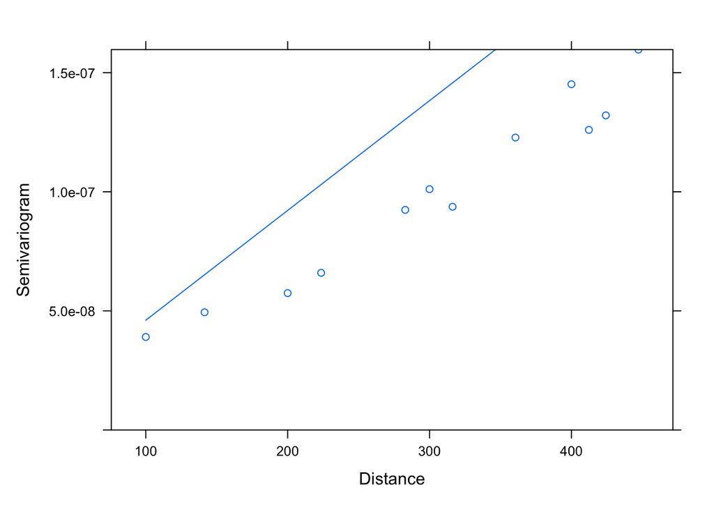

```r
#make a variogram with that, examines fit of raw model residuals to error model
plot(Variogram(onesp_exp, maxDist = max_dist)) #has a super tiny nugget (non 0 y intercept)
```

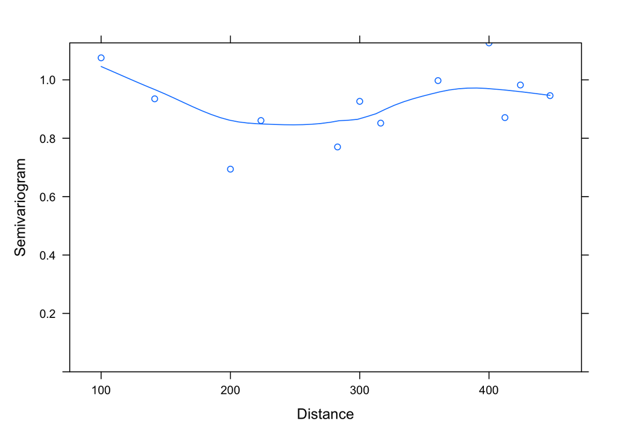

```r
#model does not fit error very well, try seeing if residuals should be normally distributed
plot(Variogram(onesp_exp, resType='normalized', maxDist = max_dist))
```

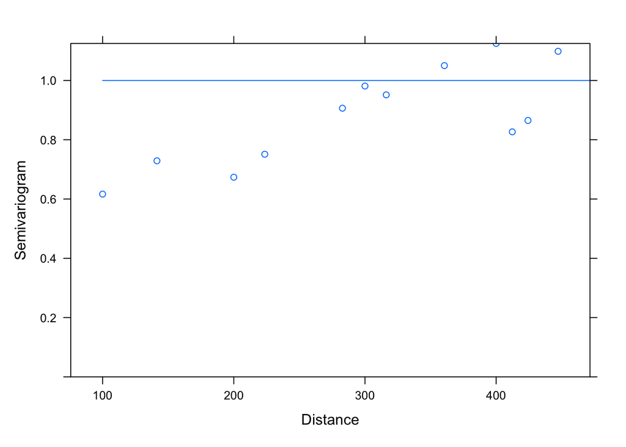

```r
#that looks like residuals are normally distributed

#address the nugget: exponential
onesp_exp_nug <- update(onesp_exp, corr=corExp(c(0.5, 0.1), form=~x + y, nugget=T))
plot(Variogram(onesp_exp_nug, maxDist = max_dist)) #not a great fit
```

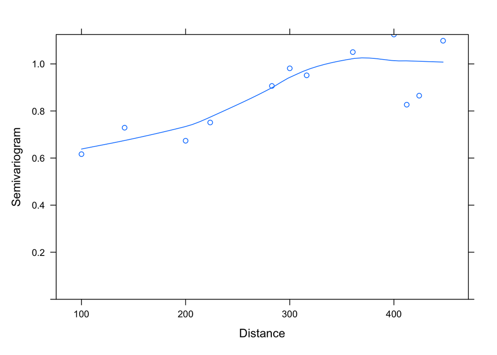

```r
plot(Variogram(onesp_exp_nug, resType='n', maxDist = max_dist)) #residuals look normally distributed
```

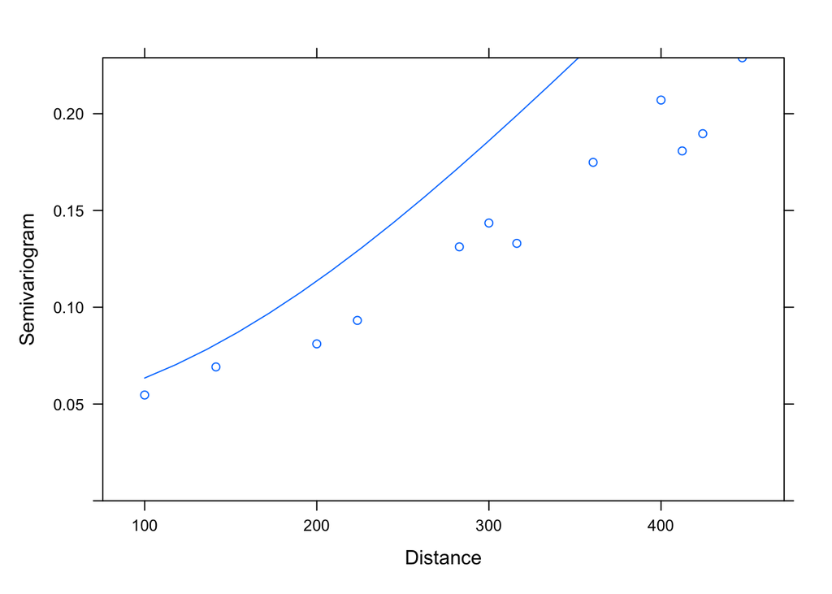

```r
#address the nugget: rational quadratic error model
onesp_rat_nug<-update(onesp_exp, corr=corRatio(form=~x + y, nugget=T))
plot(Variogram(onesp_rat_nug, maxDist = max_dist)) #still not a great fit
```

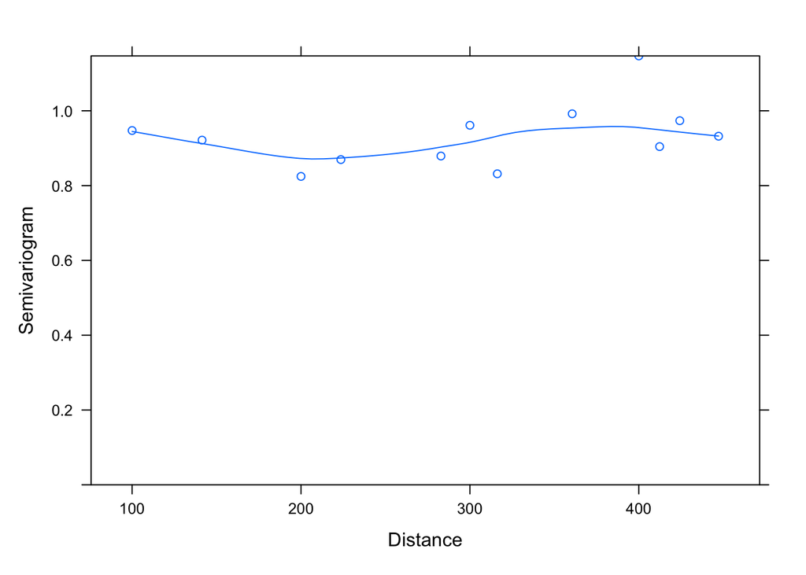

```r
plot(Variogram(onesp_rat_nug, resType='n', maxDist = max_dist)) #residuals look normally distributed
```

- Model 2: include all of the species as predictor variables

```r
#Making Model 2: include all species as predictor variables

gls_prespec <- gls(Drypetes.standleyi ~ Cordia.lasiocalyx + Hirtella.triandra + Picramnia.latifolia + Quassia.amara + Tabernaemontana.arborea + Trattinnickia.aspera + Xylopia.macrantha, data = bci_sub)
summary(gls_prespec)
```

```
## Generalized least squares fit by REML
##   Model: Drypetes.standleyi ~ Cordia.lasiocalyx + Hirtella.triandra +      Picramnia.latifolia + Quassia.amara + Tabernaemontana.arborea +      Trattinnickia.aspera + Xylopia.macrantha
##   Data: bci_sub
##        AIC      BIC    logLik
##   307.1163 322.7554 -144.5582
##
## Coefficients:
##                             Value Std.Error   t-value p-value
## (Intercept)             -1.051752 2.1175346 -0.496687  0.6220
## Cordia.lasiocalyx        0.428920 0.2039316  2.103255  0.0415
## Hirtella.triandra        0.122279 0.0802638  1.523462  0.1351
## Picramnia.latifolia      0.662259 0.6358905  1.041468  0.3036
## Quassia.amara            4.085661 2.2842770  1.788602  0.0809
## Tabernaemontana.arborea -0.249725 0.1491192 -1.674667  0.1014
## Trattinnickia.aspera     1.349323 0.7147412  1.887848  0.0660
## Xylopia.macrantha        0.548832 0.1468772  3.736672  0.0006
##
##  Correlation:
##                         (Intr) Crd.ls Hrtll. Pcrmn. Qss.mr Tbrnm. Trttn.
## Cordia.lasiocalyx       -0.618
## Hirtella.triandra       -0.212 -0.354
## Picramnia.latifolia      0.025 -0.019 -0.381
## Quassia.amara            0.163 -0.378  0.307 -0.302
## Tabernaemontana.arborea -0.708  0.245  0.163 -0.113  0.148
## Trattinnickia.aspera    -0.139  0.187 -0.311  0.308 -0.708 -0.144
## Xylopia.macrantha       -0.140 -0.125  0.156 -0.463  0.314  0.279 -0.294
##
## Standardized residuals:
##         Min          Q1         Med          Q3         Max
## -1.87708765 -0.42701500 -0.04032793  0.23615609  3.38768871
##
## Residual standard error: 4.539713
## Degrees of freedom: 50 total; 42 residual
```

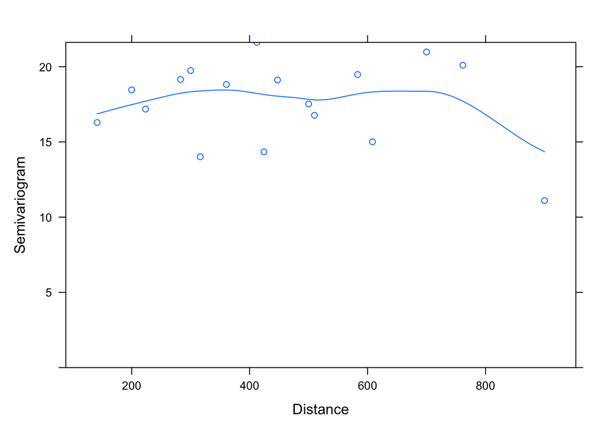

```r
#use function Variogram for all predictor species
vario_prespec <- Variogram(gls_prespec, form= ~ x + y, resType = 'response')
# note the default of the Variogram function is to compute normalized residuals
plot(vario_prespec)
```

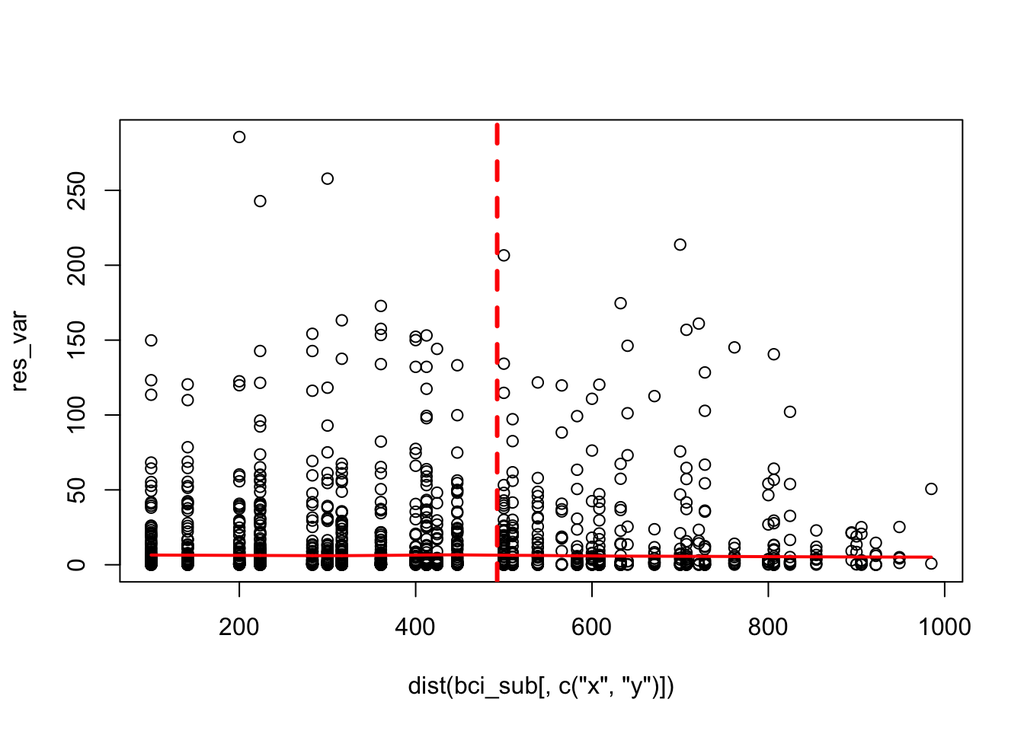

```r
#compare to a plot we make on our own
res <- residuals(gls_prespec)
res_var <- dist(res)^2 * 0.5
plot(dist(bci_sub[, c('x', 'y')]), res_var)
lines(lowess(dist(bci_sub[, c('x', 'y')]), res_var), col='red', lwd=2)
abline(v = max_dist, col='red', lwd=3, lty=2)
```

```r
#based on the variograms, autocorrelation signal seems to weaken (not as drastic in the variogram and extremely flat slope in the hand made version, indicates a random spatial pattern)

#Model the spatial dependence in the residuals using one of the error structures available.
#try an AR1: most common model of spatial autocorrelation
prespec_exp <- update(gls_prespec, corr=corExp(form= ~ x + y))
summary(prespec_exp)
```

```
## Generalized least squares fit by REML
##   Model: Drypetes.standleyi ~ Cordia.lasiocalyx + Hirtella.triandra +      Picramnia.latifolia + Quassia.amara + Tabernaemontana.arborea +      Trattinnickia.aspera + Xylopia.macrantha
##   Data: bci_sub
##        AIC      BIC    logLik
##   301.6062 318.9829 -140.8031
##
## Correlation Structure: Exponential spatial correlation
##  Formula: ~x + y
##  Parameter estimate(s):
##    range
## 480.0567
##
## Coefficients:
##                             Value Std.Error  t-value p-value
## (Intercept)             2.3485197  6.154919 0.381568  0.7047
## Cordia.lasiocalyx       0.1208390  0.179811 0.672033  0.5052
## Hirtella.triandra       0.0191759  0.098501 0.194677  0.8466
## Picramnia.latifolia     0.2014516  0.509196 0.395627  0.6944
## Quassia.amara           1.2792289  1.847570 0.692385  0.4925
## Tabernaemontana.arborea 0.0674943  0.133782 0.504511  0.6165
## Trattinnickia.aspera    1.8115374  0.525147 3.449582  0.0013
## Xylopia.macrantha       0.3388574  0.156874 2.160064  0.0365
##
##  Correlation:
##                         (Intr) Crd.ls Hrtll. Pcrmn. Qss.mr Tbrnm. Trttn.
## Cordia.lasiocalyx       -0.226
## Hirtella.triandra       -0.309 -0.022
## Picramnia.latifolia      0.045 -0.066 -0.369
## Quassia.amara           -0.059 -0.304  0.321 -0.142
## Tabernaemontana.arborea -0.240 -0.016  0.288 -0.221  0.112
## Trattinnickia.aspera    -0.069  0.168 -0.237  0.212 -0.633 -0.041
## Xylopia.macrantha       -0.056 -0.137 -0.063  0.109  0.290  0.102 -0.186
##
## Standardized residuals:
##        Min         Q1        Med         Q3        Max
## -1.0051632 -0.5235683 -0.3176178  0.2208753  2.3746027
##
## Residual standard error: 8.628464
## Degrees of freedom: 50 total; 42 residual
```

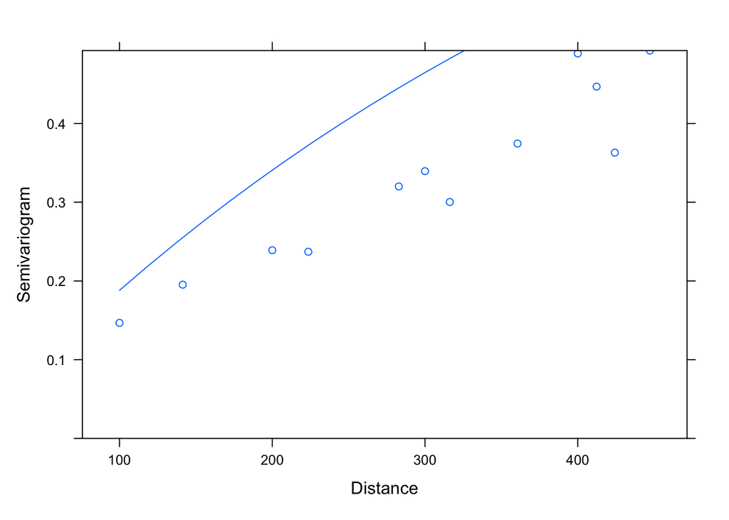

```r
#make a variogram with that, examines fit of raw model residuals to error model
plot(Variogram(prespec_exp, maxDist = max_dist))
```

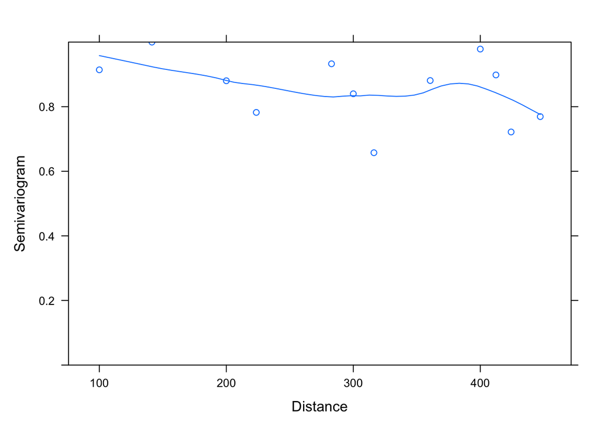

```r
#model does not fit error very well, try seeing if residuals should be normally distributed
plot(Variogram(prespec_exp, resType='normalized', maxDist = max_dist))
```

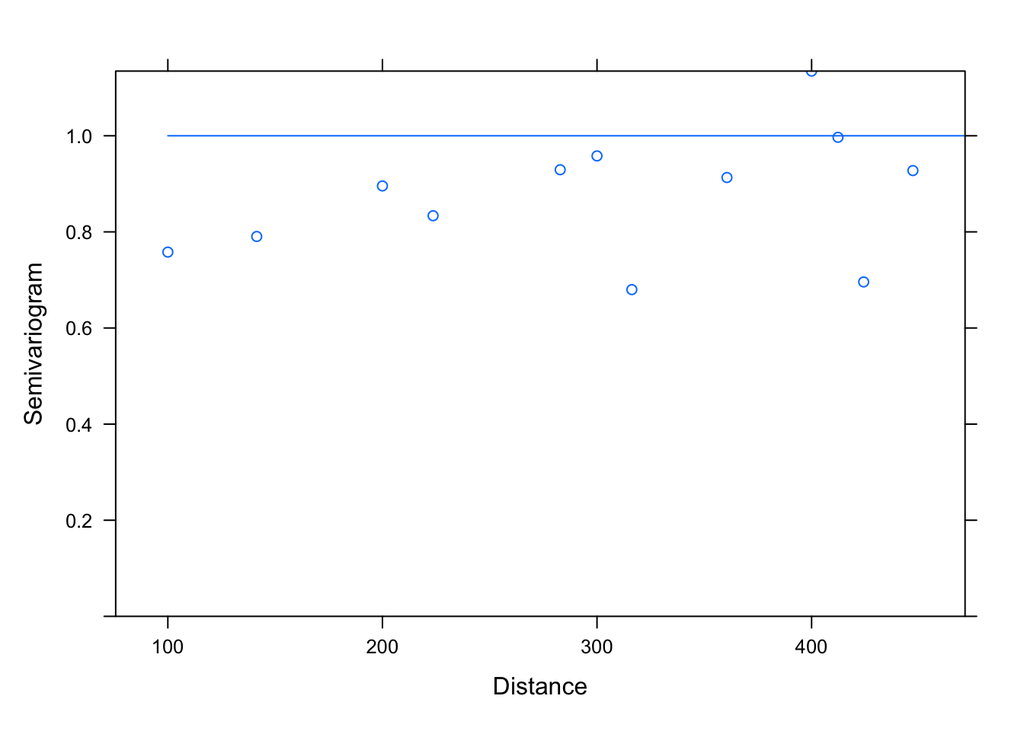

```r
#that looks good

#address the nugget: exponential
prespec_exp_nug <- update(prespec_exp, corr=corExp(c(0.5, 0.1), form=~x + y, nugget=T))
plot(Variogram(prespec_exp_nug, maxDist = max_dist)) #still not a great fit
```